# Project: Cardio Good Fitness

#### Product - Fitness

```python
# Crosstable showing relationship of Product and Usage
pd.crosstab(cardio.Product, cardio.Fitness)
```

| Fitness Product | 1 | 2 | 3 | 4 | 5 |
| --- | --- | --- | --- | --- | --- |
| TM195 | 1 | 14 | 54 | 9 | 2 |
| TM498 | 1 | 12 | 39 | 8 | 0 |
| TM798 | 0 | 0 | 4 | 7 | 29 |

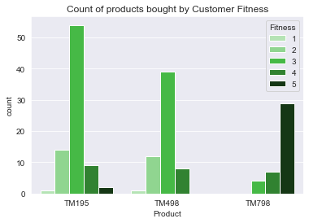

```python
# The relationship between Product and Fitness
plt.title('Count of products bought by Customer Fitness');
sns.countplot(cardio['Product'], hue=cardio['Fitness'],palette=['#adebad',"#85e085",'#33cc33','#248f24','#0f3d0f']);
```

#### Product - Education

```python
# Frequency distribution of education
m_Edu= pd.crosstab(index=cardio['Education'], columns='count')
m_Edu
```

| col_0 Education | count |
| --- | --- |
| 12 | 3 |
| 13 | 5 |
| 14 | 55 |
| 15 | 5 |
| 16 | 85 |
| 18 | 23 |
| 20 | 1 |
| 21 | 3 |

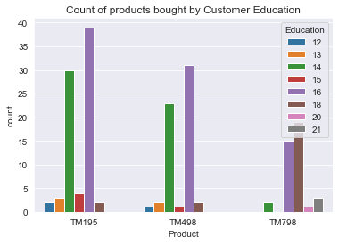

```python
# The relationship between Product and MaritalStatus
plt.title('Count of products bought by Customer Education');
sns.countplot(cardio['Product'], hue=cardio['Education']);
```

#### Product - Income

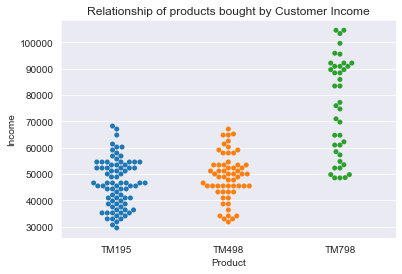

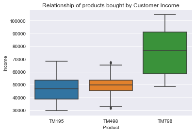

```python
# relationship between product and income
plt.title('Relationship of products bought by Customer Income');
sns.swarmplot(cardio['Product'], cardio['Income'])
plt.show()
plt.title('Relationship of products bought by Customer Income');
sns.boxplot(cardio['Product'], cardio['Income'])
plt.show()
```

#### Product - Miles

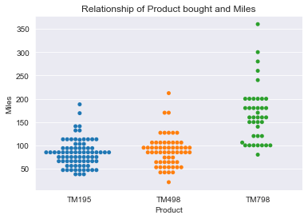

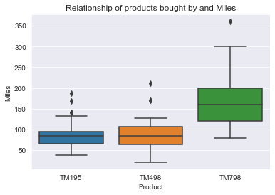

```python
# The relationship between Product and Miles
plt.title('Relationship of Product bought and Miles');
sns.swarmplot(cardio['Product'],cardio['Miles']);
plt.show();
plt.title('Relationship of products bought by and Miles');
sns.boxplot(cardio['Product'], cardio['Miles'])
plt.show();
```

#### Product - Age

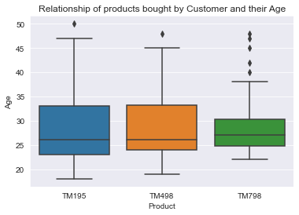

```python
# Relationship between product and customer age
plt.title('Relationship of products bought by Customer and their Age');
sns.boxplot(x=cardio['Product'], y=cardio['Age'])
plt.show()
```

#### Product - Education

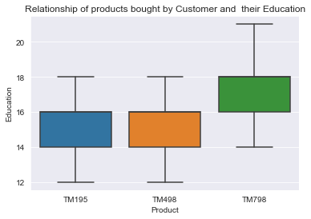

```python
# Relationship between product and customer Education
plt.title('Relationship of products bought by Customer and  their Education');
sns.boxplot(x=cardio['Product'], y=cardio['Education'])
plt.show()
```

#### Gender- Miles , Marital status-Miles, Fitness-Miles

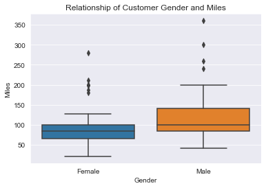

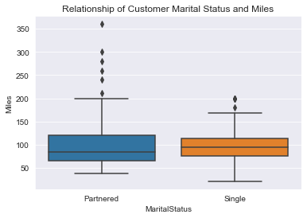

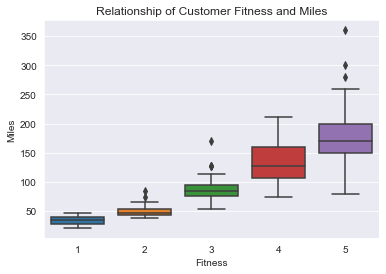

```python
# Relationship between cuatomer gender and customer marital status
plt.title('Relationship of Customer Gender and Miles');
sns.boxplot(cardio['Gender'], cardio['Miles'])
plt.show()
# Relationship between Miles and customer marital status
plt.title('Relationship of Customer Marital Status and Miles');
sns.boxplot(cardio['MaritalStatus'], cardio['Miles'])
plt.show()
# Relationship between Miles and usage
plt.title('Relationship of Customer Fitness and Miles');
sns.boxplot(cardio['Fitness'], cardio['Miles'])
plt.show()
```

### Income with other variables

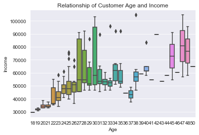

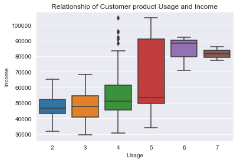

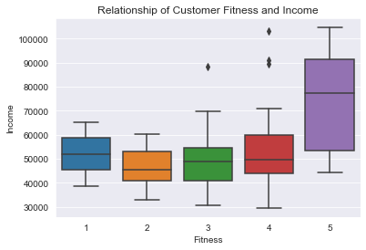

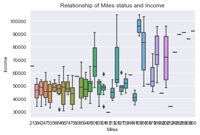

```python
# The relationship between income and Age, Usage, Fitness, Miles
# Income - Age
plt.title('Relationship of Customer Age and Income');
sns.boxplot(x=cardio['Age'], y=cardio['Income'])
plt.show();
# Income - Usage
plt.title('Relationship of Customer product Usage and Income');
sns.boxplot(x=cardio['Usage'], y=cardio['Income'])
plt.show();
# Income - Fitness
plt.title('Relationship of Customer Fitness and Income');
sns.boxplot(x=cardio['Fitness'], y=cardio['Income'])
plt.show()
# Income - Miles
plt.title('Relationship of Miles status and Income');
sns.boxplot(x=cardio['Miles'], y=cardio['Income'])
plt.show()
```

#### Observations:

-**Age:**  
Income seems to increase with Age. At age 30 50% people are in income range 50000 - 95000  
-**Usage:**  
High level of income shows more weekly usage.Many outliers are there.  
Low income also has low to moderate usage.  
-**Fitness:**  
Higher income people have more fitness level  
Average income people have moderate usage. There are some outliers with hith income.

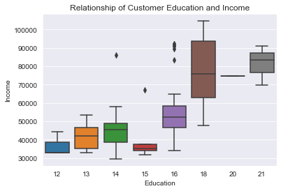

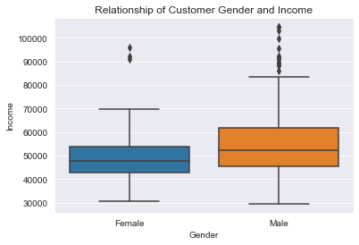

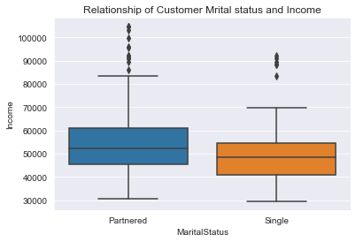

```python
# Relation between Income and Education, Gender, Marital status of customer
#Income - Education
plt.title('Relationship of Customer Education and Income');
sns.boxplot(cardio['Education'], cardio['Income'])
plt.show()
#Income - Gender
plt.title('Relationship of Customer Gender and Income');
sns.boxplot(x=cardio['Gender'], y=cardio['Income'])
plt.show()
#Income - Marital status
plt.title('Relationship of Customer Mrital status and Income');
sns.boxplot(x=cardio['MaritalStatus'], y=cardio['Income'])
plt.show()
```

#### Observations:

-**Education:**  
With high Education level 18, 50% customer income is between 63000 and 93000 . There are some outliers in level 16 and 14.  
-**Gender:**  
Males: 50% are in range 45000-62000. Many outliers are there.  
Females:50% are in range 42000-53000. A few outliers with high income.  
-**Marital Status:**  
Partnered:50% lie in range 45000 - 61000. There are many outliers with higher income  
Single: 50% lie in range 40000 - 55000. There are some outliers with hith income.

# Multivariate Analysis

### Product-wise relation between other variables

#### Product-wise - Usage - Miles

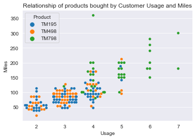

```python
# The relationship between Usage and miles according to product
plt.title('Relationship of products bought by Customer Usage and Miles');
sns.swarmplot(data=cardio, x='Usage', y='Miles', hue='Product');
```

### Observations:

TM195: usage 2-4 times a week, average is 3, from 30-90 miles. There are outliers at 5 times and higher miles.  
TM498: usage 2-4 times a week, average is 3, from 50-100 miles. There are outliers at 5 times and higher miles.  
TM798: usage 4-6 times a week, average is 5, from 100-300 miles. There are outliers at 3 and 7 times and higher miles.

#### Product-wise - Usage- Income

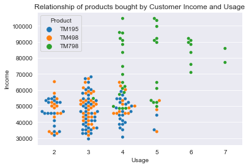

```python
# The relationship between Usage and income according to product
plt.title('Relationship of products bought by Customer Income and Usage');
sns.swarmplot(data=cardio, x='Usage', y='Income', hue='Product');
```

### Observations:

TM195: usage 2-4 times a week, average is 3, income 30000-69000. There are outliers at 5 times usage  
TM498: usage 2-4 times a week, average is 3, income 30000-69000. There are outliers at 5 times usage  
TM798: usage 4-6 times a week, average is 5,50000-90000. There are outliers at 3 and 7 times and higher income.

#### Product-wise - Usage- Age

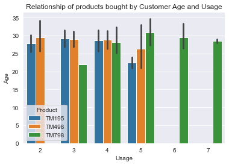

```python
# The relationship between Usage and income according to product
plt.title('Relationship of products bought by Customer Age and Usage');
sns.barplot(data=cardio, x='Usage', y='Age', hue='Product');
```

### Observations:

TM195: usage 2-4 times a week, average is 3, avergae age is 28.  
TM498: usage 2-4 times a week, average is 3,average age 29.  
TM798: usage 4-6 times a week, average is 5, average age 30.

#### Product-wise - Usage- Fitness

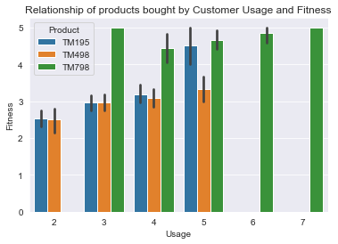

```python
# The relationship between Usage and fitness according to product
plt.title('Relationship of products bought by Customer Usage and Fitness');
sns.barplot(data=cardio, x='Usage', y='Fitness', hue='Product');
```

#### Product-wise - Usage- Education

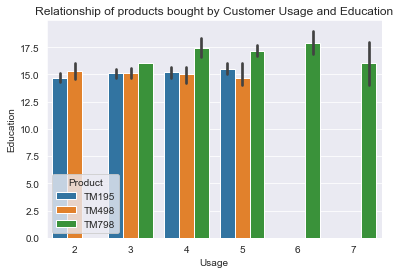

```python
# The relationship between Usage and Education according to product
plt.title('Relationship of products bought by Customer Usage and Education');
sns.barplot(data=cardio, x='Usage', y='Education', hue='Product');
```

#### Product-wise - Usage- Gender

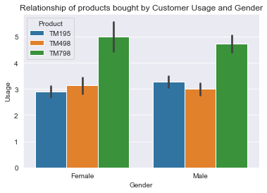

```python
# The relationship between Usage and Gender according to product
plt.title('Relationship of products bought by Customer Usage and Gender');
sns.barplot(data=cardio, x='Gender', y='Usage', hue='Product');
```

#### Product-wise - Usage- Marital Status

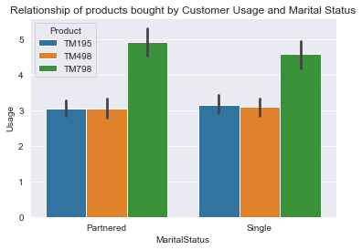

```python
# The relationship between Usage and Gender according to product
plt.title('Relationship of products bought by Customer Usage and Marital Status');
sns.barplot(data=cardio, x='MaritalStatus', y='Usage', hue='Product');
```

#### Product-wise - Income- Fitness

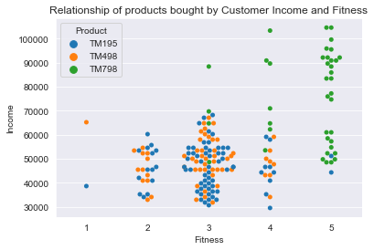

```python
# The relationship between Fitness and income according to product
plt.title('Relationship of products bought by Customer Income and Fitness');
sns.swarmplot(data=cardio, x='Fitness', y='Income', hue='Product');
```

#### Product-wise - Age - Miles

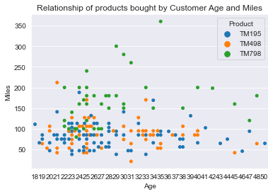

```python
# The relationship between Age and Miles according to product
plt.title('Relationship of products bought by Customer Age and Miles');
sns.swarmplot(data=cardio, x='Age', y='Miles', hue='Product');
```

#### Observations:

18-22:Most users, around 18-22 years run less than 100 miles 22-26: Most users, around 22-26 years run aound 100 miles, a few between 150 and 200  
32-35: Most users, around 32-36 years run aound 100 miles  
40-46: Few users, around 40-46 years run aound 100 miles

#### Product-wise - Age - Income

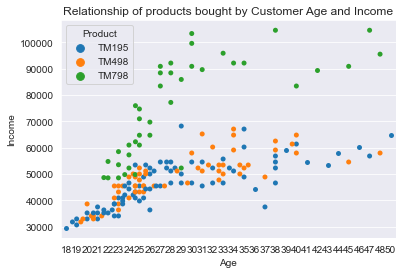

```python
# The relationship between Age and income according to product
plt.title('Relationship of products bought by Customer Age and Income');
sns.swarmplot(data=cardio, x='Age', y='Income', hue='Product');
```

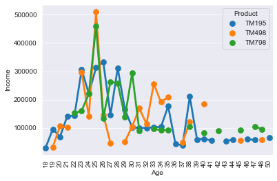

```python
# The Product wise relationship between Age and  Income
sns.pointplot(x='Age', y='Income', hue='Product',data=cardio, estimator=sum, ci=None);
plt.xticks(rotation=90); # To rotate the x axis labls
```

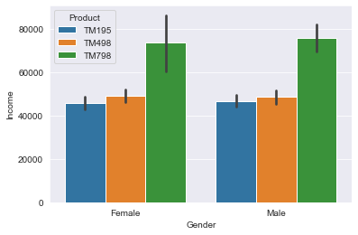

```python
# Relationship between MaritalStatus, Usage and Fitness
sns.barplot(data=cardio, x='Gender', y='Income', hue='Product')
```

#### Product-wise - Income - Miles

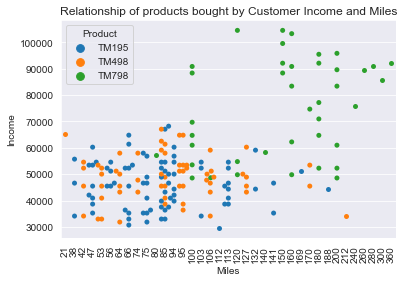

```python
# The relationship between Age and income according to product
plt.title('Relationship of products bought by Customer Income and Miles');
sns.swarmplot(data=cardio, x='Miles', y='Income', hue='Product');
plt.xticks(rotation=90);
```

## Observations:

Product vs Miles:  
TM789: 50% users run between 200 and 125 miles. median is 160 miles. few outlier at 350 miles.  
TM489: 50% users run between 110 and 65 miles. median is 80 miles. few outlier between 170 and 210 miles.  
TM195: 50% users run between 100 and 70 miles. median is 80 miles. few outlier between 140 and 200 miles.  
Product vs Age:  
TM789: 50% users ages are between 25 and 31 years. median is 27. Many outlier at ages 39 to 48.  
TM489: 50% users ages are between 24 and 34 years. median is 26. few outliers at 47 years.  
TM195: 50% users ages are between 23 and 34 years. median is 26. few outlier at age 50.

#### Age - Income - Gender

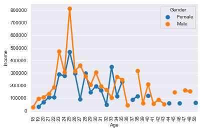

```python
# The Gender wise relationship between Age and  Income
sns.pointplot(x='Age', y='Income', hue='Gender',data=cardio, estimator=sum, ci=None);
plt.xticks(rotation=90); # To rotate the x axis labls
```

#### Education - Income - Gender

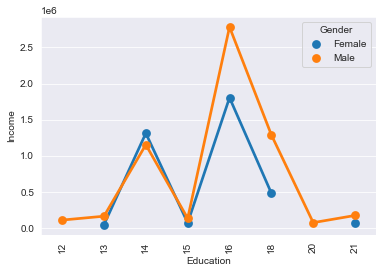

```python
# The Gender wise relationship between Education and  Income
sns.pointplot(x='Education', y='Income', hue='Gender',data=cardio, estimator=sum, ci=None);
plt.xticks(rotation=90); # To rotate the x axis labls
```

#### Product - Gender - Marital status

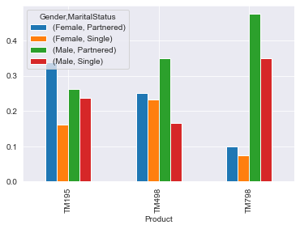

```python
# Relationship between Product and user grouped by gender and marital status
pd.crosstab(cardio.Product,[cardio.Gender, cardio.MaritalStatus], normalize='index').plot.bar(stacked=0)
```

#### Gender-Usage-Fitness

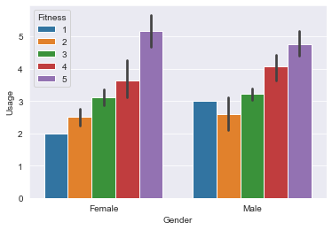

```python
# Relationship between Gender, Usage and Fitness
plt.figsize=(20,10)
sns.barplot(data=cardio, x='Gender', y='Usage', hue='Fitness')
plt.show()
```

### Observation:

Both Female and Male users who workout more than 5 times consider themselves more fit. Weekly Usage and fitness level seems to correlate.

#### Product - Fitness- Marital status

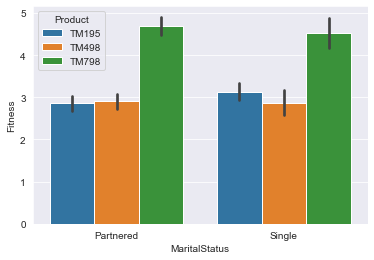

```python
# Relationship between MaritalStatus, Usage and Fitness
sns.barplot(data=cardio, x='MaritalStatus', y='Fitness', hue='Product')
```

#### Usage- Income- Gender

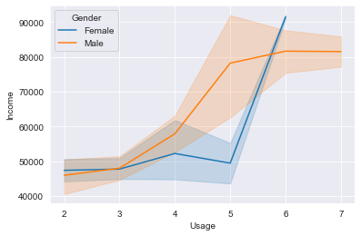

```python
sns.lineplot(x="Usage", y="Income", ci=95, data=cardio, hue='Gender')
plt.ylabel('Income')
plt.xlabel('Usage')
plt.show()
```

### Observation:

Male users useage of machines seems to icrease with the increase of income. Female users income does not seem to increase much with usage except for the very high income.

## Product TM195 data

```python
# Taking out only TM195 data
df_195 = cardio[cardio.Product=='TM195']
df_195.describe()
```

|  | Age | Education | Usage | Fitness | Income | Miles |
| --- | --- | --- | --- | --- | --- | --- |
| count | 80.000000 | 80.000000 | 80.000000 | 80.00000 | 80.00000 | 80.000000 |
| mean | 28.550000 | 15.037500 | 3.087500 | 2.96250 | 46418.02500 | 82.787500 |
| std | 7.221452 | 1.216383 | 0.782624 | 0.66454 | 9075.78319 | 28.874102 |
| min | 18.000000 | 12.000000 | 2.000000 | 1.00000 | 29562.00000 | 38.000000 |
| 25% | 23.000000 | 14.000000 | 3.000000 | 3.00000 | 38658.00000 | 66.000000 |
| 50% | 26.000000 | 16.000000 | 3.000000 | 3.00000 | 46617.00000 | 85.000000 |
| 75% | 33.000000 | 16.000000 | 4.000000 | 3.00000 | 53439.00000 | 94.000000 |
| max | 50.000000 | 18.000000 | 5.000000 | 5.00000 | 68220.00000 | 188.000000 |

### Observation:

#### Crosstab- Product - Usage, Gender-Fitness of TM195

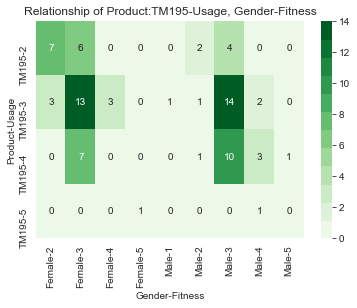

```python
# Relationship between product, usage, gender and fitness of TM195
plt.title('Relationship of Product:TM195-Usage, Gender-Fitness');
colormap=sns.color_palette("Greens",12)
sns.heatmap(pd.crosstab([df_195.Product, df_195.Usage], [df_195.Gender, df_195.Fitness]),
            cmap=colormap, annot=True, cbar=True)
```

### Observation:

Max number of users are Male users, they use it 3 times a week Max number of users in females, also use 3 times a week

#### Crosstab- Product - Usage, Marital status-Fitness of TM195

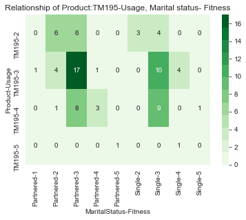

```python
# Relationship between product, usage, gender and fitness of TM195
plt.title('Relationship of Product:TM195-Usage, Marital status- Fitness');
sns.heatmap(pd.crosstab([df_195.Product, df_195.Usage], [df_195.MaritalStatus, df_195.Fitness]),
            cmap=colormap, annot=True, cbar=True)
```

### Observation:

Max number of users are partnered users, they use it 3 times a week Max number of users in singles, also use 3 times a week

#### Correlation graph of TM195

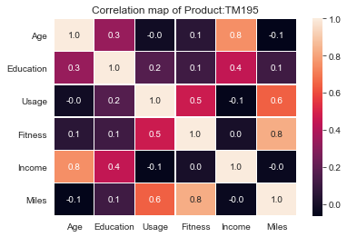

```python
# Heat map to show correlation of only TM195
plt.title('Correlation map of Product:TM195');
sns.heatmap(df_195.corr(), annot=True,linewidths=.5, fmt= '.1f' )
plt.show()
```

#### Usage-Miles of TM195

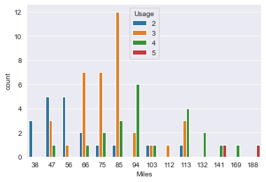

```python
# Miles count of TM195
sns.countplot(df_195['Miles'], hue=df_195['Usage']);
```

### Observation:

Max number of usage is 85 miles, 3 times a week

## Product TM498 data

```python
# Taking out only TM498 data
df_498 = cardio[cardio.Product=='TM498']
df_498.describe()
```

|  | Age | Education | Usage | Fitness | Income | Miles |
| --- | --- | --- | --- | --- | --- | --- |
| count | 60.000000 | 60.000000 | 60.000000 | 60.00000 | 60.000000 | 60.000000 |
| mean | 28.900000 | 15.116667 | 3.066667 | 2.90000 | 48973.650000 | 87.933333 |
| std | 6.645248 | 1.222552 | 0.799717 | 0.62977 | 8653.989388 | 33.263135 |
| min | 19.000000 | 12.000000 | 2.000000 | 1.00000 | 31836.000000 | 21.000000 |
| 25% | 24.000000 | 14.000000 | 3.000000 | 3.00000 | 44911.500000 | 64.000000 |
| 50% | 26.000000 | 16.000000 | 3.000000 | 3.00000 | 49459.500000 | 85.000000 |
| 75% | 33.250000 | 16.000000 | 3.250000 | 3.00000 | 53439.000000 | 106.000000 |
| max | 48.000000 | 18.000000 | 5.000000 | 4.00000 | 67083.000000 | 212.000000 |

### Observation:

Average user age is ~29, average income ~49000, average number of days used is 3 , average fitness is 3 and Average miles run is 87.9 50% User ages from 24-33, education 14-16, usage and fitness 3, income 45000-53000

#### Crosstab- Product - Usage, Gender-Fitness of TM498

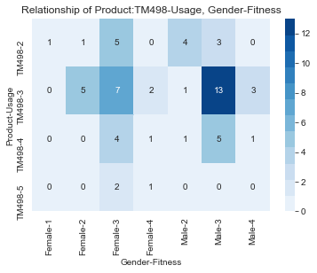

```python
# Relationship between product, usage, gender and fitness of TM498
plt.title('Relationship of Product:TM498-Usage, Gender-Fitness');
colormap2=sns.color_palette("Blues",12)
sns.heatmap(pd.crosstab([df_498.Product, df_498.Usage], [df_498.Gender, df_498.Fitness]),
            cmap=colormap2, annot=True, cbar=True)
```

### Observation:

Max number of users are Male users, they use it 3 times a week Max number of users in females, also use 3 times a week

#### Crosstab- Product - Usage, Marital status-Fitness of TM498

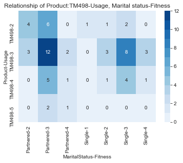

```python
# Relationship between product, usage, gender and fitness of TM498
plt.title('Relationship of Product:TM498-Usage, Marital status-Fitness');
sns.heatmap(pd.crosstab([df_498.Product, df_498.Usage], [df_498.MaritalStatus, df_498.Fitness]), cmap=colormap2, annot=True, cbar=True)
```

### Observation:

Max number of users are partnered users, they use it 3 times a week, Fitness:3 Max number of users in singles, also use 3 times a week Fitness:3

#### Correlation map of TM498

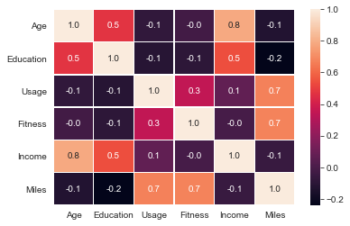

```python
# Heat map to show correlation
sns.heatmap(df_498.corr(), annot=True,linewidths=.5, fmt= '.1f' )
plt.show()
```

#### Usage - Miles of TM498

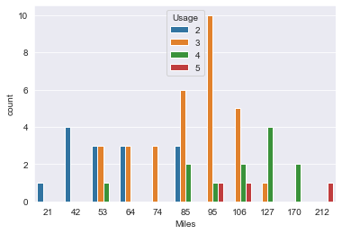

```python
# Miles count of TM498
sns.countplot(df_498['Miles'], hue=df_498['Usage']);
```

### Observation:

Max number of usage is 95 miles, 3 times a week

## Product TM798 data

```python
# Taking out only TM798
df_798 = cardio[cardio.Product=='TM798']
df_798.describe()
```

|  | Age | Education | Usage | Fitness | Income | Miles |
| --- | --- | --- | --- | --- | --- | --- |
| count | 40.000000 | 40.000000 | 40.000000 | 40.000000 | 40.00000 | 40.000000 |
| mean | 29.100000 | 17.325000 | 4.775000 | 4.625000 | 75441.57500 | 166.900000 |
| std | 6.971738 | 1.639066 | 0.946993 | 0.667467 | 18505.83672 | 60.066544 |
| min | 22.000000 | 14.000000 | 3.000000 | 3.000000 | 48556.00000 | 80.000000 |
| 25% | 24.750000 | 16.000000 | 4.000000 | 4.000000 | 58204.75000 | 120.000000 |
| 50% | 27.000000 | 18.000000 | 5.000000 | 5.000000 | 76568.50000 | 160.000000 |
| 75% | 30.250000 | 18.000000 | 5.000000 | 5.000000 | 90886.00000 | 200.000000 |
| max | 48.000000 | 21.000000 | 7.000000 | 5.000000 | 104581.00000 | 360.000000 |

### Observation:

#### Crosstab- Product - Usage, Gender-Fitness of TM798

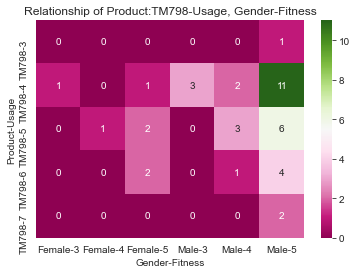

```python
# Relationship between product, usage, gender and fitness of TM798
plt.title('Relationship of Product:TM798-Usage, Gender-Fitness');
sns.heatmap(pd.crosstab([df_798.Product, df_798.Usage], [df_798.Gender, df_798.Fitness]),
            cmap="PiYG", annot=True, cbar=True)
```

### Observation:

Max number of users are Male users with fitness: 5, they use it 4 times a week Max number of users in females with fitness 5, also use 5-6 times a week

#### Crosstab- Product - Usage, Marital Status-Fitness of TM798

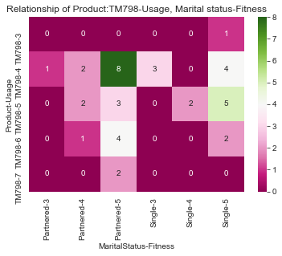

```python
# Relationship between product, usage, gender and fitness of TM798
plt.title('Relationship of Product:TM798-Usage, Marital status-Fitness');
sns.heatmap(pd.crosstab([df_798.Product, df_798.Usage], [df_798.MaritalStatus, df_798.Fitness]),
            cmap="PiYG", annot=True, cbar=True)
```

### Observation:

Max number of users are partnered users, they use it 4 times a week, Fitness:5 Max number of users in singles, also use 5 times a week Fitness:5

#### Correlation map of TM798

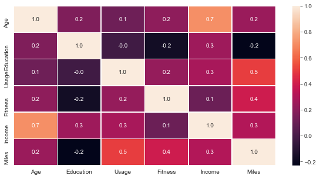

```python
# Heat map to show correlation between factors of TM798
plt.figure(figsize=(10,5))
sns.heatmap(df_798.corr(), annot=True,linewidths=.5, fmt= '.1f' )
plt.show()
```

#### Usage-Miles of TM798

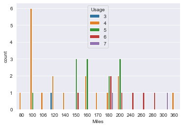

```python
# Miles count of TM798
sns.countplot(df_798['Miles'], hue=df_798['Usage']);
```

### Observation:

Max number of usage is 100 miles, 4 times a week

#### Crosstab of Product - Education

```python
# Relationship between Product and user education
pd.crosstab(cardio.Product,cardio.Education).T
```

| Product Education | TM195 | TM498 | TM798 |
| --- | --- | --- | --- |
| 12 | 2 | 1 | 0 |
| 13 | 3 | 2 | 0 |
| 14 | 30 | 23 | 2 |
| 15 | 4 | 1 | 0 |
| 16 | 39 | 31 | 15 |
| 18 | 2 | 2 | 19 |
| 20 | 0 | 0 | 1 |
| 21 | 0 | 0 | 3 |

#### Crosstab of Product - Gender-Usage

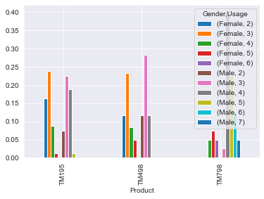

```python
# the dpi of my monitor is 120
my_dpi=120
# make a figure with the follwing figsize
plt.figure(figsize=(400/my_dpi, 300/my_dpi), dpi=my_dpi)
pd.crosstab(cardio.Product,[cardio.Gender, cardio.Usage], normalize='index').plot.bar(align='center',stacked=0)
plt.show()
```

#### Crosstab of Product -Usage, Gender-Education

```python
# Relationship between Product , usage and user grouped by gender and Education
pd.crosstab([cardio.Product,cardio.Usage],[cardio.Gender, cardio.Education]).T
```

| Gender | Product Usage Education | TM195 2 | TM195 3 | TM195 4 | TM195 5 | TM498 2 | TM498 3 | TM498 4 | TM498 5 | TM798 3 | TM798 4 | TM798 5 | TM798 6 | TM798 7 |
| --- | --- | --- | --- | --- | --- | --- | --- | --- | --- | --- | --- | --- | --- | --- |
| Female | 13 | 0 | 0 | 0 | 0 | 0 | 0 | 1 | 0 | 0 | 0 | 0 | 0 | 0 |
|  | 14 | 7 | 10 | 1 | 0 | 3 | 7 | 0 | 2 | 0 | 0 | 0 | 0 | 0 |
|  | 15 | 2 | 0 | 0 | 0 | 0 | 0 | 0 | 0 | 0 | 0 | 0 | 0 | 0 |
|  | 16 | 4 | 8 | 6 | 1 | 3 | 6 | 4 | 1 | 0 | 0 | 1 | 1 | 0 |
|  | 18 | 0 | 1 | 0 | 0 | 1 | 1 | 0 | 0 | 0 | 1 | 2 | 1 | 0 |
|  | 21 | 0 | 0 | 0 | 0 | 0 | 0 | 0 | 0 | 0 | 1 | 0 | 0 | 0 |
| Male | 12 | 0 | 1 | 1 | 0 | 1 | 0 | 0 | 0 | 0 | 0 | 0 | 0 | 0 |
|  | 13 | 0 | 2 | 1 | 0 | 0 | 0 | 1 | 0 | 0 | 0 | 0 | 0 | 0 |
|  | 14 | 4 | 4 | 4 | 0 | 1 | 7 | 3 | 0 | 0 | 1 | 0 | 0 | 1 |
|  | 15 | 1 | 0 | 0 | 1 | 0 | 1 | 0 | 0 | 0 | 0 | 0 | 0 | 0 |
|  | 16 | 1 | 10 | 9 | 0 | 5 | 9 | 3 | 0 | 1 | 7 | 4 | 1 | 0 |
|  | 18 | 0 | 1 | 0 | 0 | 0 | 0 | 0 | 0 | 0 | 6 | 5 | 3 | 1 |
|  | 20 | 0 | 0 | 0 | 0 | 0 | 0 | 0 | 0 | 0 | 1 | 0 | 0 | 0 |
|  | 21 | 0 | 0 | 0 | 0 | 0 | 0 | 0 | 0 | 0 | 1 | 0 | 1 | 0 |

### Observations:

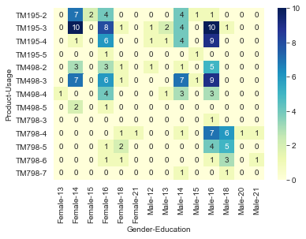

```python
sns.heatmap(pd.crosstab([cardio.Product, cardio.Usage], [cardio.Gender, cardio.Education]),
            cmap="YlGnBu", annot=True, cbar=True)
```

#### Crosstab of Product -Usage, Gender-Fitness

```python
# Relationship between Product , usage and user grouped by gender and Education
pd.crosstab([cardio.Product,cardio.Usage],[cardio.Gender, cardio.Fitness]).T
```

| Gender | Product Usage Fitness | TM195 2 | TM195 3 | TM195 4 | TM195 5 | TM498 2 | TM498 3 | TM498 4 | TM498 5 | TM798 3 | TM798 4 | TM798 5 | TM798 6 | TM798 7 |
| --- | --- | --- | --- | --- | --- | --- | --- | --- | --- | --- | --- | --- | --- | --- |
| Female | 1 | 0 | 0 | 0 | 0 | 1 | 0 | 0 | 0 | 0 | 0 | 0 | 0 | 0 |
|  | 2 | 7 | 3 | 0 | 0 | 1 | 5 | 0 | 0 | 0 | 0 | 0 | 0 | 0 |
|  | 3 | 6 | 13 | 7 | 0 | 5 | 7 | 4 | 2 | 0 | 1 | 0 | 0 | 0 |
|  | 4 | 0 | 3 | 0 | 0 | 0 | 2 | 1 | 1 | 0 | 0 | 1 | 0 | 0 |
|  | 5 | 0 | 0 | 0 | 1 | 0 | 0 | 0 | 0 | 0 | 1 | 2 | 2 | 0 |
| Male | 1 | 0 | 1 | 0 | 0 | 0 | 0 | 0 | 0 | 0 | 0 | 0 | 0 | 0 |
|  | 2 | 2 | 1 | 1 | 0 | 4 | 1 | 1 | 0 | 0 | 0 | 0 | 0 | 0 |
|  | 3 | 4 | 14 | 10 | 0 | 3 | 13 | 5 | 0 | 0 | 3 | 0 | 0 | 0 |
|  | 4 | 0 | 2 | 3 | 1 | 0 | 3 | 1 | 0 | 0 | 2 | 3 | 1 | 0 |
|  | 5 | 0 | 0 | 1 | 0 | 0 | 0 | 0 | 0 | 1 | 11 | 6 | 4 | 2 |

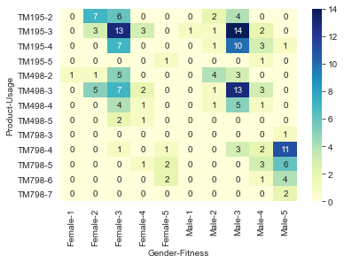

```python
sns.heatmap(pd.crosstab([cardio.Product, cardio.Usage], [cardio.Gender, cardio.Fitness]),
            cmap="YlGnBu", annot=True, cbar=True)
```

### Observation

TM195: Most Female users use it 3 times weekly and have fitness level of 3. Most Male users use it 3 times weekly and have fitness level of 3. TM498:Most Female users use it 3 times weekly and have fitness level of 3. Most Male users use it 3 times weekly and have fitness level of 3. TM798: Most Male users use it 4 times weekly and have fitness level of 5.

#### Crosstab of Product -Usage, Gender-Marital status

```python
# Relationship between Product , usage and user grouped by gender and Marital status
pd.crosstab([cardio.Product,cardio.Usage],[cardio.Gender, cardio.MaritalStatus]).T
```

| Gender | Product Usage MaritalStatus | TM195 2 | TM195 3 | TM195 4 | TM195 5 | TM498 2 | TM498 3 | TM498 4 | TM498 5 | TM798 3 | TM798 4 | TM798 5 | TM798 6 | TM798 7 |
| --- | --- | --- | --- | --- | --- | --- | --- | --- | --- | --- | --- | --- | --- | --- |
| Female | Partnered | 9 | 14 | 3 | 1 | 4 | 5 | 3 | 3 | 0 | 1 | 1 | 2 | 0 |
|  | Single | 4 | 5 | 4 | 0 | 3 | 9 | 2 | 0 | 0 | 1 | 2 | 0 | 0 |
| Male | Partnered | 3 | 9 | 9 | 0 | 6 | 12 | 3 | 0 | 0 | 10 | 4 | 3 | 2 |
|  | Single | 3 | 9 | 6 | 1 | 1 | 5 | 4 | 0 | 1 | 6 | 5 | 2 | 0 |

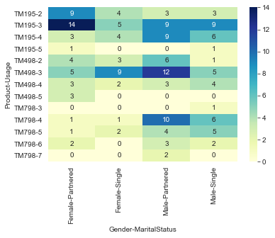

```python
sns.heatmap(pd.crosstab([cardio.Product, cardio.Usage], [cardio.Gender, cardio.MaritalStatus]),
            cmap="YlGnBu", annot=True, cbar=True)
```

### Observations:

TM195: Most users are partnered females who use it 3 times weekly TM498: Most users are partnered males who use it 3 times weekly TM798: Most users are partnered males who use it 4 times weekly

#### Means of numeric data according to product

```python
pd.pivot_table(cardio, values=None, index='Product', columns=None, aggfunc='mean', fill_value=None, margins=False, dropna=True, margins_name='All', observed=True)
```

| Product | Age | Education | Fitness | Income | Miles | Usage |
| --- | --- | --- | --- | --- | --- | --- |
| TM195 | 28.55 | 15.037500 | 2.9625 | 46418.025 | 82.787500 | 3.087500 |
| TM498 | 28.90 | 15.116667 | 2.9000 | 48973.650 | 87.933333 | 3.066667 |
| TM798 | 29.10 | 17.325000 | 4.6250 | 75441.575 | 166.900000 | 4.775000 |

#### Means of income according to product

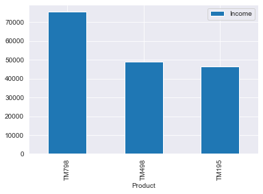

```python
# Relationship between Product and Income
cardio.groupby(by=['Product'])['Income'].mean().reset_index().sort_values(['Income'], ascending=False).head(10).plot(x='Product',y='Income',
                                                                                                           kind='bar')
plt.title='Product vs Income'
```

### Observation:

Product TM798 is bought by users with higher income, average income 75000. Product TM498 is bought by users with average income 49000 and T195 is bought by users with income 46000.

#### Means of Miles according to product

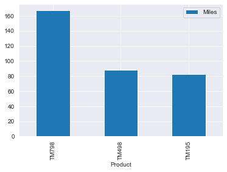

```python
# Relationship between Product and Miles
cardio.groupby(by=['Product'])['Miles'].mean().reset_index().sort_values(['Miles'], ascending=False).head(10).plot(x='Product',y='Miles',
                                                                                                           kind='bar')
```

### Observation:

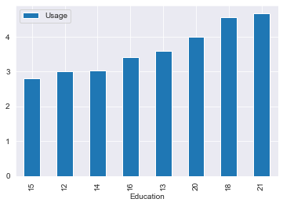

```python
cardio.groupby(by=['Education'])['Usage'].mean().reset_index().sort_values(['Usage']).tail(10).plot(x='Education',y='Usage',
                                                                                                           kind='bar')
```

### Observation:

Users with Higher Education do seem to workout more often in a week. Most users have higher education

### Conclusion:

1. Customers who are married, have less buying power and average level of fitness seem to prefer TM195.
2. Customers who have moderate buying power and average level of fitness seem to prefer TM498.
3. Mostly male customers, have high buying power and high level of fitness seem to buy TM798.  
   **Ideal Customer Profile**  
   **TM195:** Young male and female married customers(23-33)  
   Bachelor/masters  
   With less buying power 38K-53K  
   Workout in moderation: 3  
   Moderate fitness level.: 3  
   **TM498:**Young males and females (23-33)  
   With moderate buying power.45K-53K  
   Workout in moderation: 3  
   Moderate fitness level.: 3  
   **TM798:**Young Males (25-30)  
   With high buying power:58K-91K  
   Excessive workout: 4-5  
   High fitness level.: 5